# Cincinnati Reds Assessment

Zach Houghtaling

2022-10-23

## Part A

```r
library(readxl)
library(tidyverse)
library(randomForest)
library(xgboost)
library(tictoc)
library(caret)
library(baseballr)
library(shiny)
library(rsconnect)
initial_pitches <- read_xlsx("C:/Users/zacha/OneDrive/Desktop/Career Work/Example Projects/Reds Project/2023 Analytics Internship Problem Dataset.xlsx")
```

Before we create any models or analysis, we must thoroughly investigate our dataset and all the variables included

```r
#Hold the original data frame, view the data frame
pitches <- initial_pitches
#str(pitches)
#Some variables do not have the proper variable type so we will have to correct that

#Recode the variables to the correct type
pitches$THROW_SIDE_KEY <- factor(pitches$THROW_SIDE_KEY)
pitches$BAT_SIDE_KEY <- factor(pitches$BAT_SIDE_KEY)
pitches$PITCH_NUMBER <- as.numeric(pitches$PITCH_NUMBER)
pitches$PITCH_RESULT_KEY <- factor(pitches$PITCH_RESULT_KEY)
pitches$EVENT_RESULT_KEY <- factor(pitches$EVENT_RESULT_KEY)
pitches$PITCH_TYPE_KEY <- factor(pitches$PITCH_TYPE_KEY)
pitches$HORIZONTAL_BREAK <- as.numeric(pitches$HORIZONTAL_BREAK)
pitches$INDUCED_VERTICAL_BREAK <- as.numeric(pitches$INDUCED_VERTICAL_BREAK)
pitches$SPIN_DIRECTION <- as.numeric(pitches$SPIN_DIRECTION)

#Double check the type and view the factors' levels
#str(pitches)
pitches %>%
  select_if(is.factor) %>%
  sapply(levels)
```

```
## $THROW_SIDE_KEY
## [1] "L" "R"
##
## $BAT_SIDE_KEY
## [1] "L" "R"
##
## $PITCH_RESULT_KEY
## [1] "BallCalled"     "FoulBall"       "HitByPitch"     "InPlay"
## [5] "NULL"           "StrikeCalled"   "StrikeSwinging"
##
## $EVENT_RESULT_KEY
##  [1] "balk"                         "batter_interference"
##  [3] "catcher_interf"               "caught_stealing_2b"
##  [5] "caught_stealing_3b"           "caught_stealing_home"
##  [7] "defensive_indiff"             "double"
```

[output cut: 23 more lines]

```r
#Hold this data frame for part B
visuals <- pitches %>% filter(PITCHER_KEY=='A'|PITCHER_KEY=='B')

#Loop to view all NA values
for(i in 1:length(pitches)){
  if(i == 1){
    print("NA Values by variable:")
  }
  print(paste0(colnames(pitches[i]),":",sum(is.na(pitches[i]))))
}
```

```
## [1] "NA Values by variable:"
## [1] "GAME_CODE:0"
## [1] "PITCHER_KEY:0"
## [1] "THROW_SIDE_KEY:0"
## [1] "BAT_SIDE_KEY:0"
## [1] "INNING_KEY:0"
## [1] "BATTER_IN_INNING_KEY:0"
## [1] "PITCH_NUMBER:1054"
## [1] "CURRENT_BALLS:0"
## [1] "CURRENT_STRIKES:0"
## [1] "PITCH_RESULT_KEY:0"
## [1] "EVENT_RESULT_KEY:0"
## [1] "PITCH_TYPE_KEY:0"
## [1] "RELEASE_SPEED:72"
## [1] "PLATE_SPEED:91"
```

[output cut: 24 more lines]

There are the most missing values for INDUCED_VERTICAL_BREAK as expected since that is our response variable. The hawkeye or trackman tracker also appears to occasionally miss RELEASE_EXTENSION, HORIZONTAL_BREAK, as well as SPIN_RATE and SPIN_DIRECTION. This will make random forest modeling difficult if some of these are missed in our test set of player A and B’s second half pitches.

That being said, we do need to split the dataset into training and validation with our test set being player A and player B’s second half pitches.

```r
pitches <- pitches %>%
  dplyr::mutate(id = row_number()) %>%
  drop_na(PITCH_NUMBER)

#Set aside all playerA and playerB pitches to possibly double check
#their first half ranges of INDUCED_VERTICAL_BREAK later on
playerA <- pitches %>%
  dplyr::filter(PITCHER_KEY=="A")
playerB <- pitches %>%
  dplyr::filter(PITCHER_KEY=="B")

test <- pitches %>%
  dplyr::filter((PITCHER_KEY=="A"& is.na(INDUCED_VERTICAL_BREAK))|
                (PITCHER_KEY=="B"& is.na(INDUCED_VERTICAL_BREAK)))
paste0(round((nrow(test)/nrow(pitches))*100,3),
       "% of the population is in the test as pitches player A & B threw in the 2nd half")
```

```
## [1] "0.515% of the population is in the test as pitches player A & B threw in the 2nd half"
```

```r
#Print out that 0.515% of the population is in the test  as pitches player A & B threw in the 2nd half

#Get the remainder of the observations without the test set
pitches_no_response <- pitches %>%
  filter(!(id %in% test$id)) %>%
  drop_na(INDUCED_VERTICAL_BREAK)
#Rows were removed without INDUCED_VERTICAL_BREAK since there would be no response variable to predict and compare in those rows

#70-30 split of the remainder of our dataset
set.seed(17) #replicable seed
train <- pitches_no_response %>% sample_frac(0.7)
validation <- anti_join(pitches_no_response, train, by = 'id')

#Remove the id variable which is just
#the row number from each data frame
train <- train %>% dplyr::select(-c(id))
validation <- validation %>% dplyr::select(-c(id))
test <- test %>% dplyr::select(-c(id))
```

Now that the data has been split 70-30 to get the most accurate INDUCED_VERTICAL_BREAK,my baseball intuition still says we should split it up by pitch type creating new data sets of train, validation, and test based on player A & player B’s pitch repertoire

```r
types <- factor(test$PITCH_TYPE_KEY)
pitch_types <- levels(types)
pitch_names <- c("Curveball", "Change Up", "Fastball",
                 "Four Seam FB", "Sinker", "Slider", "Unknown")
```

We will now have to create a list of data for each of the pitch types for train split by pitch type. We also must remove throw side for Sinker & Unidentified since only lefties vs righty batters with null events can properly model our test for these cases

```r
train_pitches <- NULL
train_pitches_x <- NULL
train_pitches_y <- NULL
train_pitches[[i]] <- list(seq(1:length(pitch_types)))

options(na.action='na.pass')
for(i in 1:length(pitch_types)){
  if(pitch_types[i] != 'SI' & pitch_types[i] != 'UN'){
    train_pitches[[i]] <- train %>%
      dplyr::filter(PITCH_TYPE_KEY==pitch_types[i])

    #Add dummy variables for categorical factors for xgboost
    train_pitches_x[[i]] <- model.matrix(
      INDUCED_VERTICAL_BREAK ~ .-GAME_CODE -PITCHER_KEY,
      data = train_pitches[[i]])[, -1]
  }
  else if(pitch_types[i] == 'SI'){
    #For sinkers only lefty vs right with null events
    train_pitches[[i]] <- train %>%
      dplyr::filter(PITCH_TYPE_KEY=='SI' & THROW_SIDE_KEY=='L' &
                    BAT_SIDE_KEY=='R' & EVENT_RESULT_KEY=='NULL')

    #Add dummy variables for categorical factors for xgboost
    train_pitches[[i]]$PITCHER_KEY <- NULL
    train_pitches_x[[i]] <- model.matrix(
      INDUCED_VERTICAL_BREAK ~ .-GAME_CODE -THROW_SIDE_KEY
      -BAT_SIDE_KEY -EVENT_RESULT_KEY,
      data = train_pitches[[i]])[, -1]
  }
  #Otherwise it should be unknown of only lefty v right
  else{
    train_pitches[[i]] <- train %>%
      dplyr::filter(PITCH_TYPE_KEY=='UN' & THROW_SIDE_KEY=='L' &
                    BAT_SIDE_KEY=='R')

    #Add dummy variables for categorical factors for xgboost
    train_pitches[[i]]$PITCHER_KEY <- NULL
    train_pitches_x[[i]] <- model.matrix(
      INDUCED_VERTICAL_BREAK ~ . -GAME_CODE -THROW_SIDE_KEY,
      data = train_pitches[[i]])[, -1]
  }

  #Create a list of vectors of the response variable by pitch type
  train_pitches_y[[i]] <- train_pitches[[i]]$INDUCED_VERTICAL_BREAK
}
```

We also have to do the same loop of the data by pitch type for our validation

```r
validation_pitches <- NULL
validation_pitches_x <- NULL
validation_pitches_y <- NULL
for(i in 1:length(pitch_types)){
  if(pitch_types[[i]] != 'SI' & pitch_types[i] != 'UN'){
    validation_pitches[[i]] <- validation %>%
      dplyr::filter(PITCH_TYPE_KEY==pitch_types[i])

    #Add dummy variables for categorical factors for xgboost
    validation_pitches_x[[i]] <- model.matrix(
      INDUCED_VERTICAL_BREAK ~ .-GAME_CODE -PITCHER_KEY,
      data = validation_pitches[[i]])[, -1]
  }
  #For sinkers only lefty vs right with null events
  else if(pitch_types[i] == 'SI'){
    validation_pitches[[i]] <- validation %>%
      dplyr::filter(PITCH_TYPE_KEY=='SI' & THROW_SIDE_KEY=='L' &
                    BAT_SIDE_KEY=='R' & EVENT_RESULT_KEY=='NULL')

    #Add dummy variables for categorical factors for xgboost
    validation_pitches[[i]]$PITCHER_KEY <- NULL
    validation_pitches_x[[i]] <- model.matrix(
      INDUCED_VERTICAL_BREAK ~ .-GAME_CODE -THROW_SIDE_KEY
      -BAT_SIDE_KEY -EVENT_RESULT_KEY,
      data = validation_pitches[[i]])[, -1]
  }
  #Otherwise it should be unknown of only lefty v right
  else{
    validation_pitches[[i]] <- validation %>%
      dplyr::filter(PITCH_TYPE_KEY=='UN' & THROW_SIDE_KEY=='L' &
                    BAT_SIDE_KEY=='R')

    #Add dummy variables for categorical factors for xgboost
    validation_pitches[[i]]$PITCHER_KEY <- NULL
    validation_pitches_x[[i]] <- model.matrix(
      INDUCED_VERTICAL_BREAK ~ . -GAME_CODE -THROW_SIDE_KEY,
      data = validation_pitches[[i]])[, -1]
  }

  #Create a list of vectors of the response variable by pitch type
  validation_pitches_y[[i]] <- validation_pitches[[i]]$INDUCED_VERTICAL_BREAK
}
```

And finally, we have to loop through to split our test set by pitch type

```r
test_pitches <- NULL
test_pitches_x <- NULL
test_pitches_y <- NULL
for(i in 1:length(pitch_types)){
  if(pitch_types[i] != 'SI' & pitch_types[i] != 'UN'){
    test_pitches[[i]] <- test %>%
      dplyr::filter(PITCH_TYPE_KEY==pitch_types[i])

    #Add dummy variables for categorical factors for xgboost
    test_pitches_x[[i]] <- model.matrix(
      INDUCED_VERTICAL_BREAK ~ .-GAME_CODE -PITCHER_KEY,
      data = test_pitches[[i]])[, -1]
  }
  #For sinkers only lefty vs right with null events because that's all we can make assumptions on for the testing set
  else if(pitch_types[i] == 'SI'){
    test_pitches[[i]] <- test %>%
      dplyr::filter(PITCH_TYPE_KEY=='SI')

    #Add dummy variables for categorical factors for xgboost
    test_pitches[[i]]$PITCHER_KEY <- NULL
    test_pitches_x[[i]] <- model.matrix(
      INDUCED_VERTICAL_BREAK ~ .-GAME_CODE -THROW_SIDE_KEY
      -BAT_SIDE_KEY -EVENT_RESULT_KEY,
      data = test_pitches[[i]])[, -1]
  }
  #Otherwise it should be unknown of only lefty v right
  else{
    test_pitches[[i]] <- test %>%
      dplyr::filter(PITCH_TYPE_KEY==pitch_types[i])

    #Add dummy variables for categorical factors for xgboost
    # Drop the "ID" and "Value" columns
    test_pitches[[i]]$PITCHER_KEY <- NULL
    test_pitches_x[[i]] <- model.matrix(
      INDUCED_VERTICAL_BREAK ~ .-GAME_CODE -THROW_SIDE_KEY,
      data = test_pitches[[i]])[, -1]
  }
}
```

As far as modeling techniques, we set the data up for to create 7 XGBoost (Extreme Gradient Boosting) models for each of the 7 pitches. Since there are missing values throughout the data set a random forest could not be created without imputation or removal of these values so I opted to use the XGBoost for my predictions

```r
#10 fold cross validation model testing the root mean squared error
#for 800 different rounds - computationally intensive
#Will find out which number of rounds is the best based on the testing

#Initialize lists for variables we will use
best.xgb <- list(seq(1:length(pitch_types)))
xg_important_vars <- list(seq(1:length(pitch_types)))
```

Since the XGBoost tuning is very computationally intensive this section is all commented out. It loops through: 200 rounds finding the minimum test rmse on 10-fold cross validation max depth values from 1 to 10 eta values of 0.1, 0.15, 0.2, 0.25, 0.3 sub sample values of 0.25, 0.5, 0.75, 1.

```r
#tic()
#Initialize lists for variables we will use
#xgModel <- list(seq(1:length(pitch_types)))
#xgb.caret <- list(seq(1:length(pitch_types)))
#xgb.results <- list(seq(1:length(pitch_types)))
#nrounds <- list(seq(1:length(pitch_types)))

#eta <- NULL
#max_depth <- NULL
#subsample <- NULL


#for(i in 1:length(pitch_types)){
  #set.seed(17)
  #xgModel[[i]] <- xgb.cv(data = train_pitches_x[[i]],
                          #label = train_pitches_y[[i]],
                          #nrounds = 200,
                          #objective = "reg:squarederror", nfold=10)
  ###Which number of rounds has the lowest test rmse
  #nrounds[[i]] <- which(xgModel[[i]]$evaluation_log$test_rmse_mean                 #== min(xgModel[[i]]$evaluation_log$test_rmse_mean))
  #nround_finder <- data.frame(
  #  cbind(
  #    as.numeric(xgModel[[i]]$evaluation_log$iter),
  #    as.numeric(xgModel[[i]]$evaluation_log$test_rmse_mean)
  #    )
  #  )
  #print(ggplot(data=nround_finder,aes(x=X1,y=X2)) +
    #geom_point() +
    #xlab('Iteration') +
    #ylab('Test RMSE Mean Value') +
    #ggtitle('Finding nrounds Value'))

  ###tuning through caret initialization
  #tune_grid <- expand.grid(
  #  nrounds = nrounds[[i]],
  #  eta = c(0.1, 0.15, 0.2, 0.25, 0.3),
  #  max_depth = c(1:10),
  #  gamma = c(0),
  #  colsample_bytree = 1,
  #  min_child_weight = 1,
  #  subsample = c(0.25, 0.5, 0.75, 1)
  #)

  ###Only do this the first time before the best model is found (computationally intensive)
  ###Find the model that is tuned with the best parameters that were chosen above to test (1 to 10 different depth levels, 5 potential eta values and 4 potential subsample values)
  #set.seed(17)
  #xgb.caret[[i]] <- train(x = train_pitches_x[[i]], y = train_pitches_y[[i]],
  #                   method = "xgbTree",
  #                   tuneGrid = tune_grid,
  #                   trControl = trainControl(method = 'cv', # Using 10-fold cross-validation
  #                                            number = 10))
  ###Look for the lowest point on this graph
  #print(plot(xgb.caret[[i]]))


###Inputting the eta, max_depth, subsample, and nrounds that minimized
###the RMSE in the caret cross validation model
#  eta[i] <- xgb.caret[[i]]$bestTune$eta
#  max_depth[i] <- xgb.caret[[i]]$bestTune$max_depth
#  subsample[i] <- xgb.caret[[i]]$bestTune$subsample
#  nrounds[i] <- xgb.caret[[i]]$bestTune$nrounds
#}
#toc() #Running this took 89508.81 sec but we now have the best tune
```

Now that the values for eta, max_depth, subsample, and nrounds were acquired from tuning for the smallest root mean squared error value, we can create our best XGBoost model split up by the different pitch types.

```r
#Manually inputting the best XGBoost Tuning Parameters for our 7 models acquired from xgb.caret's minimized rmse
eta <- c(0.10,0.25,0.10,0.20,0.10,0.25,0.10)
max_depth <- c(8,6,10,6,8,6,10)
subsample <- c(0.75,0.75,0.50,0.75,0.75,1.00,0.50)
nrounds <- c(199,200,200,200,200,200,200)

#Loop to get the best model for each of the 7 models
for(i in 1:length(pitch_types)){
  set.seed(17)
  best.xgb[[i]] <- xgboost(data=train_pitches_x[[i]],
                           label=train_pitches_y[[i]],
                           eta=eta[i],
                           nrounds = nrounds[i],
                           max_depth=max_depth[i],
                           subsample=subsample[i])

  #Which variables were important in our best xgboost model
  set.seed(17)
  xg_important_vars[[i]] <- xgb.importance(
    feature_names = colnames(train_pitches_x[[i]]),
    model = best.xgb[[i]])

  xgb.ggplot.importance(xgb.importance(
    feature_names = colnames(train_pitches_x[[i]]),
    model = best.xgb[[i]]))
}
```

Now that we’ve created the models, we want to go back and check how they perform on our validation data set (30% of the data). Before we check our findings with the validation, however, the average, deviance, and deviance squared need to be calculated of our response values

```r
avg <- list(seq(1:length(pitch_types)))
dev <- list(seq(1:length(pitch_types)))
dev_sq <- list(seq(1:length(pitch_types)))


#Used for all R-squared calculations as the Sum of Deviance Squared
for(i in 1:length(pitch_types)){
  avg[[i]] <- mean(validation_pitches_y[[i]])
  dev[[i]] <- validation_pitches_y[[i]] - avg[[i]]
  dev_sq[[i]] <- sum(dev[[i]]^2)
}
```

We need to now go back and check the XGBoost Models we created to see how they performed on the validation data set. We will calculate the Mean Absolute Error and the R-Squared value for each of the 7 models

```r
xg_predictions <- list(seq(1:length(pitch_types)))
xg_diff <- list(seq(1:length(pitch_types)))
xg_diff_sq <- list(seq(1:length(pitch_types)))
xg_rsq <- list(seq(1:length(pitch_types)))
MAE_xg <- list(seq(1:length(pitch_types)))

for(i in 1:length(pitch_types)){
  xg_predictions[[i]] <- predict(best.xgb[[i]],
                                 validation_pitches_x[[i]])
  xg_diff[[i]] <- validation_pitches_y[[i]] - xg_predictions[[i]]
  xg_diff_sq[[i]] <- sum(xg_diff[[i]]^2)
  xg_rsq[[i]] <- 1-(xg_diff_sq[[i]]/dev_sq[[i]])
  MAE_xg[[i]] <- mean(abs(xg_diff[[i]]))
  print(paste0("The R-Squared value for the ",pitch_names[i],
               " model was: ", round(xg_rsq[[i]],4)))
  print(paste0("The MAE value for the ",pitch_names[i],
                " model was: ", round(MAE_xg[[i]],3)))
}
```

```
## [1] "The R-Squared value for the Curveball model was: 0.9761"
## [1] "The MAE value for the Curveball model was: 0.531"
## [1] "The R-Squared value for the Change Up model was: 0.9654"
## [1] "The MAE value for the Change Up model was: 0.503"
## [1] "The R-Squared value for the Fastball model was: 0.9394"
## [1] "The MAE value for the Fastball model was: 0.439"
## [1] "The R-Squared value for the Four Seam FB model was: 0.9519"
## [1] "The MAE value for the Four Seam FB model was: 0.584"
## [1] "The R-Squared value for the Sinker model was: 0.9794"
## [1] "The MAE value for the Sinker model was: 0.334"
## [1] "The R-Squared value for the Slider model was: 0.9607"
## [1] "The MAE value for the Slider model was: 0.483"
## [1] "The R-Squared value for the Unknown model was: 0.9936"
## [1] "The MAE value for the Unknown model was: 0.508"
```

Our 7 models were able to explain between 93.9% (Fastball) to 99.4% (Unknown) of the variation of VERTICAL_INDUCED_BREAK using each of the 7 different XGBoost models on our validation data set (30% of the original data). The mean absolute error of each of the models predictions ranged from 0.334 inches (Sinker Model) to 0.584 inches (Four Seam Fastball Model) of the actual VERTICAL_INDUCED_BREAK when tested on the validation data set.

```r
xg_predictions_test <- list(seq(1:length(pitch_types)))
predictions <- NULL
test_vals <- NULL

for(i in 1:length(pitch_types)){
  xg_predictions_test[[i]] <- predict(best.xgb[[i]],test_pitches_x[[i]])
  predictions <- rbind(data.frame(predictions),
                       data.frame(xg_predictions_test[[i]]))
  test_vals <- bind_rows(data.frame(test_vals),
                         data.frame(test_pitches[[i]]))
}
colnames(predictions) <- c("PREDICTED_INDUCED_VERTICAL_BREAK")
predictions <- cbind(predictions,test_vals)
#Add back in the "B" for the UN/SI Pitch Types that only "B" Throws
predictions$PITCHER_KEY <- ifelse(
  is.na(predictions$PITCHER_KEY),"B",predictions$PITCHER_KEY)
write.csv(predictions,'break.csv',row.names=F)
```

We have now created break.csv and completed part A! As a next step for Part A, and with more than 8 hours for the assessment I would have done additional models and compared to create an ensemble model that could minimize the prediction error even further.

## Part B

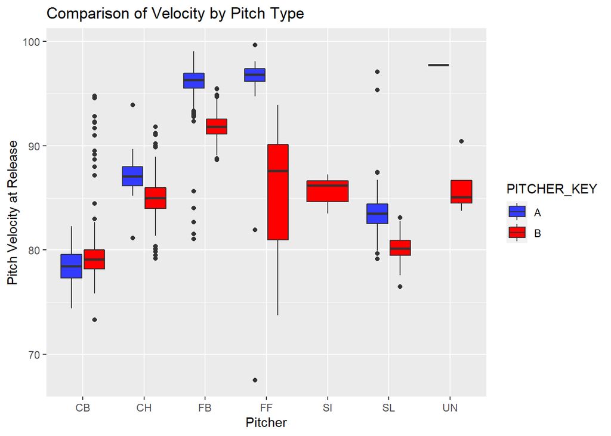

```r
library(shiny)
#str(visuals)
group.colors <- c(CB = "#333BFF", CH = "#CC6600", FB ="#9633FF",
                  FF = "#FF0000", SI = "#E3DB71", SL = "#ADD8E6",
                  UN = "#000000")
pitcher.colors <- c(A= "#333BFF", B = "#FF0000")

ggplot(visuals,aes(PITCH_TYPE_KEY, RELEASE_SPEED,fill=PITCHER_KEY)) +
  geom_boxplot() +
  ylab('Pitch Velocity at Release') +
  xlab('Pitcher') +
  ggtitle('Comparison of Velocity by Pitch Type') +
  scale_fill_manual(values=pitcher.colors)
```

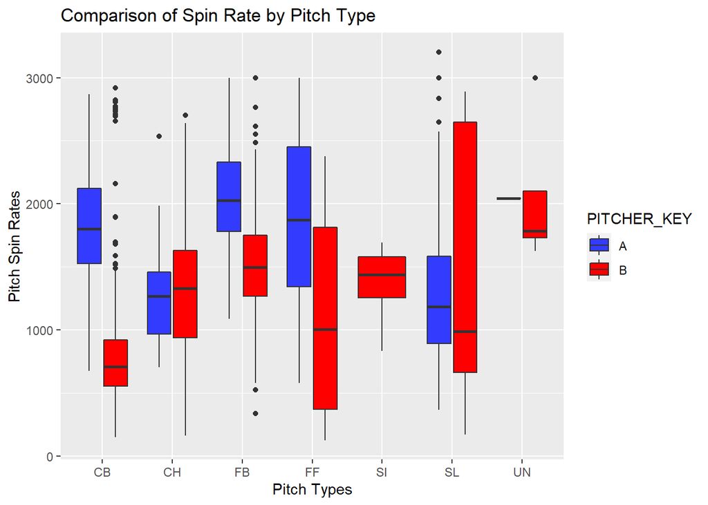

```r
ggplot(visuals,aes(PITCH_TYPE_KEY, SPIN_RATE,fill=PITCHER_KEY)) +
  geom_boxplot() +
  #facet_wrap(~ PITCH_TYPE_KEY) +
  ylab('Pitch Spin Rates') +
  xlab('Pitch Types') +
  ggtitle('Comparison of Spin Rate by Pitch Type') +
  scale_fill_manual(values=pitcher.colors)
```

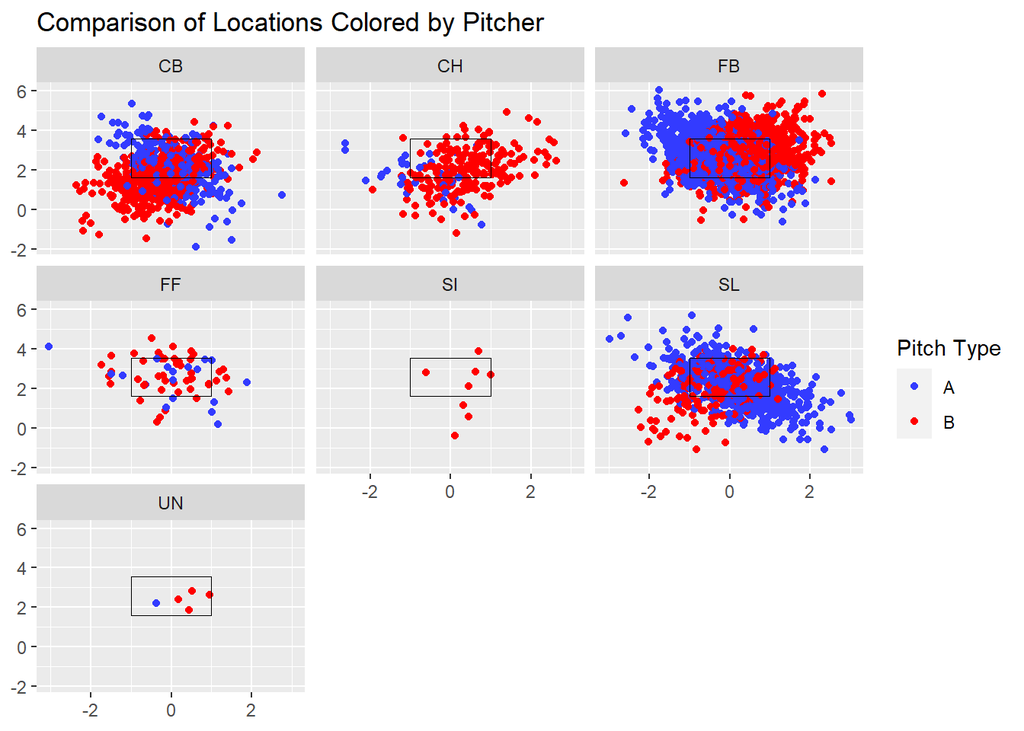

```r
ggplot(visuals, aes(PLATE_X, PLATE_Z)) +
  geom_point(aes(color = PITCHER_KEY)) +
  facet_wrap(~ PITCH_TYPE_KEY) +
  geom_rect(mapping = aes(ymax = 3.56, ymin = 1.6,
                          xmax = -1, xmin = 1), alpha = 0, size=0.2,
                          colour = "black") +
  ylab(NULL) +
  xlab(NULL) +
  ggtitle('Comparison of Locations Colored by Pitcher') +
  labs(color="Pitch Type") +
  scale_color_manual(values=pitcher.colors)
```

I created these visuals in ggplot all split up by pitch types to show the Pitch Velocities for all of player A and B’s pitches, the Spin Rates for all of player A and B’s pitches and the location of player A and B’s pitches. If a proper time component was included as either their game sequence or the date, I would have plotted some trends over time but there was no certainty in the order of the games player A and player B played in. These plots will need to be remade as R Shiny Plots to have 4 dashboards (An additional one of all pitch types overlaid on one graph for each pitcher) to compare the two players.

```r
load <- function() {
  if ( require( "ggplot2" ) != TRUE ) {
    print( "Required library 'ggplot2' could not be loaded" )
    return( FALSE )
  } else if ( require( "shiny" ) != TRUE ) {
    print( "Required library 'shiny' could not be loaded" )
    return( FALSE )
  } else {
    return( TRUE )
  }
}

if ( load() == TRUE ) {
  hist_ui1 <- fluidPage(
    titlePanel( "Pitch Type Distribution"),
    sidebarLayout(
      sidebarPanel(
        checkboxGroupInput(
         "pitcher",
         "Player:",
         c( "Player A" = "A",
            "Player B" = "B"),
         inline = TRUE,
         selected = c("A","B"),
       ),
       checkboxGroupInput(
         "pitch_type",
         "Pitch Type:",
         c( "Curveball" = "CB",
            "Change Up" = "CH",
            "Fastball" = "FB",
            "Four Seam FB" = "FF",
            "Slider" = "SL",
            "Sinker" = "SI",
            "Unknown" = "UN"),
         inline = TRUE,
         selected = c("FB"))
       ),
      sliderInput(
         "iqr",
         "Outlier IQR:",
         min = 0.5,
         max = 3.0,
         step = 0.25,
         value = 1.5
       )
     ),
      mainPanel(
        plotOutput( "distPlot" )
      )
    )

  hist_server1 <- function( input, output ) {
    output$distPlot <- renderPlot( {
  ggplot(data= (visuals %>%
                      filter(PITCHER_KEY==input$pitcher) %>%
                      filter(PITCH_TYPE_KEY == input$pitch_type)),
         aes(PITCH_TYPE_KEY, RELEASE_SPEED,fill=PITCHER_KEY)) +
  geom_boxplot(coef=input$iqr) +
  ylab('Pitch Release Velocities') +
  xlab('Pitch Type') +
  ggtitle('Comparison of Pitch Release Velocities by Pitch Type') +
  scale_fill_manual(values=pitcher.colors)
    } )
  }

  shinyApp( ui = hist_ui1, server = hist_server1 )
}
```

[output not shown]

Shiny applications not supported in static R Markdown documents

Above is the Shiny box plot of pitch velocities for each of the pitchers split by pitch type. You can select either player A or B or both. All combinations of pitch type are accepted as well. Next will be the plot of all the spin rates by pitch type.

```r
if ( load() == TRUE ) {
  hist_ui2 <- fluidPage(
    titlePanel( "Pitch Type Distribution" ),
    sidebarLayout(
      sidebarPanel(
        checkboxGroupInput(
         "pitcher",
         "Player:",
         c( "Player A" = "A",
            "Player B" = "B"),
         inline = TRUE,
         selected = c("A","B")
       ),
       checkboxGroupInput(
         "pitch_type",
         "Pitch Type:",
         c( "Curveball" = "CB",
            "Change Up" = "CH",
            "Fastball" = "FB",
            "Four Seam FB" = "FF",
            "Slider" = "SL",
            "Sinker" = "SI",
            "Unknown" = "UN"),
         inline = TRUE,
         selected = c("CB"))
       ),
      sliderInput(
         "iqr",
         "Outlier IQR:",
         min = 0.5,
         max = 3.0,
         step = 0.25,
         value = 1.5
       )
     ),
      mainPanel(
        plotOutput( "distPlot" )
      )
    )


  hist_server2 <- function( input, output ) {
    output$distPlot <- renderPlot( {
  ggplot(data= (visuals %>%
                      filter(PITCHER_KEY==input$pitcher) %>%
                      filter(PITCH_TYPE_KEY == input$pitch_type)),
         aes(PITCH_TYPE_KEY, SPIN_RATE,fill=PITCHER_KEY)) +
  geom_boxplot(coef=input$iqr) +
  ylab('Pitch Spin Rates (RPM)') +
  xlab('Pitcher') +
  ggtitle('Comparison of Spin Rate by Pitch Type') +
  scale_fill_manual(values=pitcher.colors)
    } )
  }


  shinyApp( ui = hist_ui2, server = hist_server2 )
}
```

Shiny applications not supported in static R Markdown documents

Above we created the Shiny box plot of all the spin rates by pitch type. Similar to the last plot you can select all combinations of pitcher and pitch type. Next is the location of each of the pitch types.

```r
if ( load() == TRUE ) {
  hist_ui3 <- fluidPage(
    titlePanel( "Pitch Type Distribution" ),
    sidebarLayout(
      sidebarPanel(
        checkboxGroupInput(
         "pitcher",
         "Player:",
         c( "Player A" = "A",
            "Player B" = "B"),
         inline = TRUE,
         selected = c("A","B")
       ),
       checkboxGroupInput(
         "pitch_type",
         "Pitch Type:",
         c( "Curveball" = "CB",
            "Change Up" = "CH",
            "Fastball" = "FB",
            "Four Seam FB" = "FF",
            "Slider" = "SL"),
         inline = TRUE,
         selected = c("CB","CH","FB","FF",
                      "SL"))
       ),
      mainPanel(
        plotOutput( "distPlot" )
      )
    )
  )

  hist_server3 <- function( input, output ) {
    output$distPlot <- renderPlot( {
  ggplot(data= (visuals %>%
                      filter(PITCH_TYPE_KEY == input$pitch_type) %>%
                      filter(PITCHER_KEY==input$pitcher)), aes(PLATE_X, PLATE_Z)) +
  geom_point(aes(color = PITCHER_KEY)) +
  facet_wrap(~ PITCH_TYPE_KEY) +
  geom_rect(mapping = aes(ymax = 3.56, ymin = 1.6,
                          xmax = -1, xmin = 1), alpha = 0, size=0.2,
                          colour = "black") +
  ylab(NULL) +
  xlab(NULL) +
  ggtitle('Comparison of Locations Colored by Pitcher') +
  scale_color_manual(values=pitcher.colors)
    } )
  }
  shinyApp( ui = hist_ui3, server = hist_server3 )
}
```

Shiny applications not supported in static R Markdown documents

```r
if ( load() == TRUE ) {
  hist_ui4 <- fluidPage(
    titlePanel( "Pitch Type Distribution" ),
    sidebarLayout(
      sidebarPanel(
        radioButtons(
         "pitcher",
         "Player:",
         c( "Player A" = "A",
            "Player B" = "B"),
         inline = TRUE,
         selected = c("A")
       ),
       checkboxGroupInput(
         "pitch_type",
         "Pitch Type:",
         c( "Curveball" = "CB",
            "Change Up" = "CH",
            "Fastball" = "FB",
            "Four Seam FB" = "FF",
            "Slider" = "SL",
            "Sinker" = "SI",
            "Unknown" = "UN"),
         inline = TRUE,
         selected = c("CB","CH","FB","FF",
                      "SL","SI","UN"))
       ),
      mainPanel(
        plotOutput( "distPlot" )
      )
    )
  )

  hist_server4 <- function( input, output ) {
    output$distPlot <- renderPlot( {
  ggplot((visuals %>% filter(PITCH_TYPE_KEY == input$pitch_type,PITCHER_KEY==input$pitcher)), aes(PLATE_X, PLATE_Z)) +
  geom_point(aes(color = PITCH_TYPE_KEY)) +
  geom_rect(mapping = aes(ymax = 3.56, ymin = 1.6,
                          xmax = -1, xmin = 1), alpha = 0, size=0.2,
                          colour = "black") +
  ylab(NULL) +
  xlab(NULL) +
  ggtitle(paste0('Locations Colored by Pitch Type - Pitcher ',
                 input$pitcher)) +
  labs(color="Pitch Type") +
  scale_color_manual(values =group.colors)
    } )
  }
  shinyApp( ui = hist_ui4, server = hist_server4 )
}
```

Shiny applications not supported in static R Markdown documents

In this final dashboard of all selected pitch types for a pitcher only player A or B can be selected at once. You can filter by whatever pitch types are desired, however.

## Part C

Before we make a decision on the better player based on the visuals lets add a few metrics such as IP and FIP while also doing some statistical tests on that FB Velocity, CB Spin Rate, as well as their outcome percentages such as called strike % and balls put in play %

```r
#From the dataframes for players A and B we with held let's look at all of their events to calculate the outcome of their opposing balls in play
playerA_events <- playerA %>% filter(EVENT_RESULT_KEY != "NULL")
playerB_events <- playerB %>% filter(EVENT_RESULT_KEY != "NULL")
playerA_event_levels <- levels(factor(playerA_events$EVENT_RESULT_KEY))
playerB_event_levels <- levels(factor(playerB_events$EVENT_RESULT_KEY))
playerA_event_levels
```

```
##  [1] "caught_stealing_2b"        "caught_stealing_home"
##  [3] "double"                    "double_play"
##  [5] "field_out"                 "fielders_choice"
##  [7] "fielders_choice_out"       "force_out"
##  [9] "grounded_into_double_play" "hit_by_pitch"
## [11] "home_run"                  "passed_ball"
## [13] "sac_fly"                   "single"
## [15] "stolen_base_2b"            "strikeout"
## [17] "strikeout_double_play"     "triple"
## [19] "walk"                      "wild_pitch"
```

```r
playerB_event_levels
```

```
##  [1] "caught_stealing_2b"         "caught_stealing_3b"
##  [3] "caught_stealing_home"       "double"
##  [5] "double_play"                "field_error"
##  [7] "field_out"                  "fielders_choice"
##  [9] "force_out"                  "grounded_into_double_play"
## [11] "hit_by_pitch"               "home_run"
## [13] "pickoff_1b"                 "pickoff_caught_stealing_2b"
## [15] "sac_fly"                    "single"
## [17] "stolen_base_2b"             "stolen_base_3b"
## [19] "strikeout"                  "strikeout_double_play"
## [21] "triple"                     "walk"
## [23] "wild_pitch"
```

```r
#Calculate the frequency each of the results occurred for player A
playerA_results <- data.frame(playerA_event_levels)
playerA_results$playerA_Freq <- 0
for(i in 1:nrow(playerA_results)){
  playerA_results$playerA_Freq[i] <- playerA_events %>%
    filter(EVENT_RESULT_KEY==playerA_event_levels[i]) %>%
    nrow()
}

#Calculate the frequency each of the results occurred for player B
playerB_results <- data.frame(playerB_event_levels)
playerB_results$playerB_Freq <- 0
for(i in 1:nrow(playerB_results)){
  playerB_results$playerB_Freq[i] <- playerB_events %>%
    filter(EVENT_RESULT_KEY==playerB_event_levels[i]) %>%
    nrow()
}

#Join the results together and fill the NA values with 0 since that is an event with a 0 count for that pitcher
player_results <- full_join(playerA_results,playerB_results, by=c("playerA_event_levels"="playerB_event_levels"))
player_results[is.na(player_results)] <- 0

#Creating the column names for player results
outcomes <- player_results$playerA_event_levels
player_results$playerA_event_levels <- NULL
player_results <- data.frame(t(player_results))
colnames(player_results) <- outcomes

cFIP <- 3.113 #Major League FIP Constant to make it like ERA measure when
#we calculate it below

player_results <- player_results %>%
  mutate(IP=sum(strikeout,
                force_out,
                2*double_play,
                2*grounded_into_double_play,
                2*strikeout_double_play,
                caught_stealing_2b,
                caught_stealing_3b,
                caught_stealing_home,
                pickoff_1b,
                pickoff_caught_stealing_2b,
                sac_fly,
                fielders_choice_out,
                field_out)/3,
         k_per_bb=(strikeout+strikeout_double_play)/(walk),
         SBA=sum(stolen_base_2b,
                 stolen_base_3b,
                 caught_stealing_2b,
                 caught_stealing_3b,
                 caught_stealing_home,
                 strikeout_double_play,
                 pickoff_caught_stealing_2b),
         SB=sum(stolen_base_2b,
                stolen_base_3b),
         Hits_allowed=sum(single,
                          double,
                          triple,
                          home_run)) %>%
   mutate(WHIP =(walk + hit_by_pitch + Hits_allowed)/ IP,
          FIP = cFIP + (( (13*home_run) + (3*(walk+hit_by_pitch)) -
                (2*(strikeout+strikeout_double_play) )) / IP),
          SB_perc= (SB/SBA),
          CS_perc= 1-(SB/SBA))

#Pull in the Average FB Velo and CB Spin Rate to aid evaluation
player_results$Avg_FB_Velo <- 0
player_results$Avg_CB_Spin_Rate <- 0

player_results$Avg_FB_Velo[1] <- round(
  summary((playerA %>%
             filter(PITCH_TYPE_KEY=="FB"))$RELEASE_SPEED)[4],2)

player_results$Avg_FB_Velo[2] <- round(
  summary((playerB %>%
             filter(PITCH_TYPE_KEY=="FB"))$RELEASE_SPEED)[4],2)

player_results$Avg_CB_Spin_Rate[1] <- round(
  summary((playerA %>%
             filter(PITCH_TYPE_KEY=="CB"))$SPIN_RATE)[4],2)

player_results$Avg_CB_Spin_Rate[2] <- round(
  summary((playerB %>%
             filter(PITCH_TYPE_KEY=="CB"))$SPIN_RATE)[4],2)
```

Let’s check to see if the velocities and spin rates are statistically different from one another. First, however, we have to check if they have equal variances

```r
var.test(RELEASE_SPEED ~ PITCHER_KEY, data = (visuals %>% filter(PITCH_TYPE_KEY=='FB')))
```

```
##
##  F test to compare two variances
##
## data:  RELEASE_SPEED by PITCHER_KEY
## F = 1.8453, num df = 1077, denom df = 1062, p-value < 2.2e-16
## alternative hypothesis: true ratio of variances is not equal to 1
## 95 percent confidence interval:
##  1.636718 2.080388
## sample estimates:
## ratio of variances
##           1.845314
```

```r
var.test(SPIN_RATE ~ PITCHER_KEY, data = (visuals %>% filter( PITCH_TYPE_KEY=='CB')))
```

```
##
##  F test to compare two variances
##
## data:  SPIN_RATE by PITCHER_KEY
## F = 0.96796, num df = 254, denom df = 479, p-value = 0.7758
## alternative hypothesis: true ratio of variances is not equal to 1
## 95 percent confidence interval:
##  0.7830985 1.2051244
## sample estimates:
## ratio of variances
##          0.9679561
```

Since the variance test showed FB Velocity has a different variance, unequal variances will need to be specified for that t-test but not between Curveball spinrates.

```r
t.test(RELEASE_SPEED ~ PITCHER_KEY,
       data = (visuals %>%
                 filter(PITCH_TYPE_KEY=='FB')), var.equal=F)
```

```
##
##  Welch Two Sample t-test
##
## data:  RELEASE_SPEED by PITCHER_KEY
## t = 82.06, df = 1979.7, p-value < 2.2e-16
## alternative hypothesis: true difference in means between group A and group B is not equal to 0
## 95 percent confidence interval:
##  4.258471 4.467002
## sample estimates:
## mean in group A mean in group B
##        96.17280        91.81006
```

```r
t.test(SPIN_RATE ~ PITCHER_KEY,
         data = (visuals %>%
                   filter(PITCH_TYPE_KEY=='CB')),var.equal=T)
```

```
##
##  Two Sample t-test
##
## data:  SPIN_RATE by PITCHER_KEY
## t = 31.259, df = 733, p-value < 2.2e-16
## alternative hypothesis: true difference in means between group A and group B is not equal to 0
## 95 percent confidence interval:
##   961.4598 1090.3191
## sample estimates:
## mean in group A mean in group B
##        1820.843         794.954
```

There’s an overwhelming amount of statistical evidence that the Fastball velocities are somewhere between 4.26 to 4.47 mph higher for player A and the Curveball Spin Rate is between 961.46 to 1090.32 RPM higher for player A compared to player B. These statistical arguments support my claims as to player A having a strong advantage in the raw “stuff” factor considerations.

```r
print("PLAYER A PITCH RESULTS")
```

```
## [1] "PLAYER A PITCH RESULTS"
```

```r
summary(playerA$PITCH_RESULT_KEY)
```

```
##     BallCalled       FoulBall     HitByPitch         InPlay           NULL
##            751            376              8            247              0
##   StrikeCalled StrikeSwinging
##            351            293
```

```r
summary(playerA$PITCH_RESULT_KEY)[1]/nrow(playerA)
```

```
## BallCalled
##  0.3706811
```

```r
summary(playerA$PITCH_RESULT_KEY)[2]/nrow(playerA)
```

```
##  FoulBall
## 0.1855874
```

```r
summary(playerA$PITCH_RESULT_KEY)[3]/nrow(playerA)
```

```
##  HitByPitch
## 0.003948667
```

```r
summary(playerA$PITCH_RESULT_KEY)[4]/nrow(playerA)
```

```
##    InPlay
## 0.1219151
```

```r
summary(playerA$PITCH_RESULT_KEY)[5]/nrow(playerA)
```

[output not shown]

```r
summary(playerA$PITCH_RESULT_KEY)[6]/nrow(playerA)
```

```
## StrikeCalled
##    0.1732478
```

```r
summary(playerA$PITCH_RESULT_KEY)[7]/nrow(playerA)
```

```
## StrikeSwinging
##      0.1446199
```

```r
#Overall K%
playerA_K_perc <- 1-as.numeric(summary(playerA$PITCH_RESULT_KEY)[1]
 + summary(playerA$PITCH_RESULT_KEY)[3])/nrow(playerA)
playerA_K_perc
```

```
## [1] 0.6253702
```

```r
print("PLAYER B PITCH RESULTS")
```

```
## [1] "PLAYER B PITCH RESULTS"
```

```r
summary(playerB$PITCH_RESULT_KEY)
```

```
##     BallCalled       FoulBall     HitByPitch         InPlay           NULL
##            726            367              6            275              0
##   StrikeCalled StrikeSwinging
##            302            278
```

```r
summary(playerB$PITCH_RESULT_KEY)[1]/nrow(playerB)
```

```
## BallCalled
##  0.3715455
```

```r
summary(playerB$PITCH_RESULT_KEY)[2]/nrow(playerB)
```

```
##  FoulBall
## 0.1878199
```

```r
summary(playerB$PITCH_RESULT_KEY)[3]/nrow(playerB)
```

```
##  HitByPitch
## 0.003070624
```

```r
summary(playerB$PITCH_RESULT_KEY)[4]/nrow(playerB)
```

```
##    InPlay
## 0.1407369
```

```r
summary(playerB$PITCH_RESULT_KEY)[5]/nrow(playerB)
```

[output not shown]

```r
summary(playerB$PITCH_RESULT_KEY)[6]/nrow(playerB)
```

```
## StrikeCalled
##    0.1545548
```

```r
summary(playerB$PITCH_RESULT_KEY)[7]/nrow(playerB)
```

```
## StrikeSwinging
##      0.1422723
```

```r
#Overall K%
playerB_K_perc <- 1-as.numeric(summary(playerB$PITCH_RESULT_KEY)[1]
 + summary(playerB$PITCH_RESULT_KEY)[3])/nrow(playerB)
playerB_K_perc
```

```
## [1] 0.6253838
```

```r
#Testing Called Ball Statistical difference
prop.test(x = c(summary(playerA$PITCH_RESULT_KEY)[1],
  summary(playerB$PITCH_RESULT_KEY)[1]),
 n = c(nrow(playerA), nrow(playerB)))
```

```
##
##  2-sample test for equality of proportions with continuity correction
##
## data:  c(summary(playerA$PITCH_RESULT_KEY)[1], summary(playerB$PITCH_RESULT_KEY)[1]) out of c(nrow(playerA), nrow(playerB))
## X-squared = 0.00055765, df = 1, p-value = 0.9812
## alternative hypothesis: two.sided
## 95 percent confidence interval:
##  -0.03138971  0.02966091
## sample estimates:
##    prop 1    prop 2
## 0.3706811 0.3715455
```

```r
#Testing Called Strike Statistical difference
prop.test(x = c(summary(playerA$PITCH_RESULT_KEY)[6],
  summary(playerB$PITCH_RESULT_KEY)[6]),
 n = c(nrow(playerA), nrow(playerB)))
```

```
##
##  2-sample test for equality of proportions with continuity correction
##
## data:  c(summary(playerA$PITCH_RESULT_KEY)[6], summary(playerB$PITCH_RESULT_KEY)[6]) out of c(nrow(playerA), nrow(playerB))
## X-squared = 2.3997, df = 1, p-value = 0.1214
## alternative hypothesis: two.sided
## 95 percent confidence interval:
##  -0.004798061  0.042184100
## sample estimates:
##    prop 1    prop 2
## 0.1732478 0.1545548
```

```r
#Testing In play Statistical difference
prop.test(x = c(summary(playerA$PITCH_RESULT_KEY)[4],
  summary(playerB$PITCH_RESULT_KEY)[4]),
 n = c(nrow(playerA), nrow(playerB)))
```

```
##
##  2-sample test for equality of proportions with continuity correction
##
## data:  c(summary(playerA$PITCH_RESULT_KEY)[4], summary(playerB$PITCH_RESULT_KEY)[4]) out of c(nrow(playerA), nrow(playerB))
## X-squared = 2.9293, df = 1, p-value = 0.08699
## alternative hypothesis: two.sided
## 95 percent confidence interval:
##  -0.040317875  0.002674183
## sample estimates:
##    prop 1    prop 2
## 0.1219151 0.1407369
```

While I only showed 3 of the 2-prop z-tests, there was not a statistical difference for any of the proportions at an alpha-level of 0.05 meaning Player A’s slight edge in these values is insignificant

```r
player_results
```

```
##              caught_stealing_2b caught_stealing_home double double_play
## playerA_Freq                  4                    1     18           3
## playerB_Freq                  1                    1     17           2
##              field_out fielders_choice fielders_choice_out force_out
## playerA_Freq       139               1                   1         6
## playerB_Freq       147               1                   0         9
##              grounded_into_double_play hit_by_pitch home_run passed_ball
## playerA_Freq                         7            8        8           1
## playerB_Freq                        11            6        8           0
##              sac_fly single stolen_base_2b strikeout strikeout_double_play
## playerA_Freq       4     58              9       148                     1
## playerB_Freq       1     71             12       152                     2
##              triple walk wild_pitch caught_stealing_3b field_error pickoff_1b
## playerA_Freq      2   66          6                  0           0          0
## playerB_Freq      4   48          9                  2           4          2
##              pickoff_caught_stealing_2b stolen_base_3b       IP k_per_bb SBA SB
## playerA_Freq                          0              0 223.6667 2.257576  37 24
## playerB_Freq                          1              3 223.6667 3.208333  37 24
##              Hits_allowed     WHIP      FIP   SB_perc   CS_perc Avg_FB_Velo
## playerA_Freq          186 1.162444 3.238186 0.6486486 0.3513514       96.17
## playerB_Freq          186 1.073025 2.925221 0.6486486 0.3513514       91.81
##              Avg_CB_Spin_Rate
## playerA_Freq          1817.67
## playerB_Freq           794.92
```

```r
player_results %>% select(strikeout,walk,IP,WHIP,FIP)
```

```
##              strikeout walk       IP     WHIP      FIP
## playerA_Freq       148   66 223.6667 1.162444 3.238186
## playerB_Freq       152   48 223.6667 1.073025 2.925221
```

```r
player_results %>% select(Avg_FB_Velo,Avg_CB_Spin_Rate)
```

```
##              Avg_FB_Velo Avg_CB_Spin_Rate
## playerA_Freq       96.17          1817.67
## playerB_Freq       91.81           794.92
```

```r
#Player A has 148k/66bb where Player B is 152k/48bb

#Righty Player A
summary(playerA)
```

```
##    GAME_CODE         PITCHER_KEY        THROW_SIDE_KEY BAT_SIDE_KEY
##  Min.   :2.022e+18   Length:2026        L:   0         L: 998
##  1st Qu.:2.022e+18   Class :character   R:2026         R:1028
##  Median :2.022e+18   Mode  :character
##  Mean   :2.022e+18
##  3rd Qu.:2.022e+18
##  Max.   :2.022e+18
##
##    INNING_KEY    BATTER_IN_INNING_KEY  PITCH_NUMBER    CURRENT_BALLS
##  Min.   :1.000   Min.   :1.000        Min.   : 1.000   Min.   :0.0000
##  1st Qu.:2.000   1st Qu.:2.000        1st Qu.: 2.000   1st Qu.:0.0000
##  Median :3.000   Median :3.000        Median : 3.000   Median :1.0000
##  Mean   :3.006   Mean   :2.716        Mean   : 2.997   Mean   :0.9038
##  3rd Qu.:4.000   3rd Qu.:4.000        3rd Qu.: 4.000   3rd Qu.:2.0000
##  Max.   :7.000   Max.   :8.000        Max.   :10.000   Max.   :3.0000
##
##  CURRENT_STRIKES        PITCH_RESULT_KEY  EVENT_RESULT_KEY PITCH_TYPE_KEY
##  Min.   :0.0000   BallCalled    :751     NULL     :1535    FB     :1070
##  1st Qu.:0.0000   FoulBall      :376     strikeout: 148    SL     : 647
##  Median :1.0000   HitByPitch    :  8     field_out: 139    CB     : 255
##  Mean   :0.9506   InPlay        :247     walk     :  66    CH     :  35
##  3rd Qu.:2.0000   NULL          :  0     single   :  58    FF     :  18
##  Max.   :2.0000   StrikeCalled  :351     double   :  18    UN     :   1
##                   StrikeSwinging:293     (Other)  :  62    (Other):   0
##  RELEASE_SPEED    PLATE_SPEED      SPIN_RATE      SPIN_DIRECTION
##  Min.   :67.54   Min.   :61.17   Min.   : 365.5   Min.   :  6.944
##  1st Qu.:83.09   1st Qu.:76.29   1st Qu.:1386.7   1st Qu.: 91.243
##  Median :94.55   Median :86.09   Median :1820.4   Median :200.516
##  Mean   :89.72   Mean   :82.08   Mean   :1774.4   Mean   :149.860
##  3rd Qu.:96.40   3rd Qu.:87.97   3rd Qu.:2229.2   3rd Qu.:209.066
##  Max.   :99.67   Max.   :91.10   Max.   :3204.3   Max.   :258.857
##                                  NA's   :4        NA's   :9
##      SZ_TOP        SZ_BOTTOM        PLATE_X            PLATE_Z
##  Min.   :3.124   Min.   :1.413   Min.   :-3.03526   Min.   :-1.898
##  1st Qu.:3.318   1st Qu.:1.514   1st Qu.:-0.64017   1st Qu.: 1.766
##  Median :3.367   Median :1.540   Median :-0.05506   Median : 2.416
##  Mean   :3.393   Mean   :1.553   Mean   :-0.05745   Mean   : 2.457
##  3rd Qu.:3.464   3rd Qu.:1.591   3rd Qu.: 0.48453   3rd Qu.: 3.183
##  Max.   :3.658   Max.   :1.692   Max.   : 3.02561   Max.   : 6.027
##
```

[output cut: 25 more lines]

```
##  Min.   :-2.843   Min.   :-0.1115   Min.   :-21.1296   Min.   :-23.2435
##  1st Qu.:-1.603   1st Qu.: 5.5972   1st Qu.:-10.0768   1st Qu.:  0.4909
##  Median :-1.325   Median : 5.8660   Median : -6.9007   Median : 16.5536
##  Mean   :-1.376   Mean   : 5.8521   Mean   :  0.5591   Mean   :  8.6789
##  3rd Qu.:-1.156   3rd Qu.: 6.0950   3rd Qu.: 12.7109   3rd Qu.: 19.1006
##  Max.   : 1.176   Max.   : 7.6724   Max.   : 25.7149   Max.   : 23.1198
##                   NA's   :1         NA's   :7          NA's   :716
##  VERTICAL_APPROACH_ANGLE HORIZONTAL_APPROACH_ANGLE       id
##  Min.   :-14.3564        Min.   :-3.11125          Min.   :   1.0
##  1st Qu.: -7.6100        1st Qu.:-0.00473          1st Qu.: 917.2
##  Median : -5.7174        Median : 1.04660          Median :1960.5
##  Mean   : -6.0907        Mean   : 1.47293          Mean   :1998.6
##  3rd Qu.: -4.3285        3rd Qu.: 3.04707          3rd Qu.:3045.8
##  Max.   : -0.9222        Max.   : 6.53988          Max.   :3929.0
##
```

```r
#Fast, Slide, Curve, Occasional Change and Four Seam FB
#96.17 Avg FB Velo and 1820.84 Avg CB Spin Rate

#Lefty Player B
summary(playerB)
```

```
##    GAME_CODE         PITCHER_KEY        THROW_SIDE_KEY BAT_SIDE_KEY
##  Min.   :2.022e+18   Length:1954        L:1954         L: 636
##  1st Qu.:2.022e+18   Class :character   R:   0         R:1318
##  Median :2.022e+18   Mode  :character
##  Mean   :2.022e+18
##  3rd Qu.:2.022e+18
##  Max.   :2.022e+18
##
##    INNING_KEY    BATTER_IN_INNING_KEY  PITCH_NUMBER    CURRENT_BALLS
##  Min.   :1.000   Min.   : 1.000       Min.   : 1.000   Min.   :0.0000
##  1st Qu.:2.000   1st Qu.: 2.000       1st Qu.: 1.250   1st Qu.:0.0000
##  Median :3.000   Median : 2.000       Median : 3.000   Median :1.0000
##  Mean   :3.154   Mean   : 2.709       Mean   : 2.923   Mean   :0.9063
##  3rd Qu.:4.000   3rd Qu.: 3.000       3rd Qu.: 4.000   3rd Qu.:2.0000
##  Max.   :9.000   Max.   :11.000       Max.   :10.000   Max.   :3.0000
##
##  CURRENT_STRIKES        PITCH_RESULT_KEY  EVENT_RESULT_KEY PITCH_TYPE_KEY
##  Min.   :0.0000   BallCalled    :726     NULL     :1440    FB     :1057
##  1st Qu.:0.0000   FoulBall      :367     strikeout: 152    CB     : 479
##  Median :1.0000   HitByPitch    :  6     field_out: 147    CH     : 213
##  Mean   :0.8966   InPlay        :275     single   :  71    SL     : 147
##  3rd Qu.:2.0000   NULL          :  0     walk     :  48    FF     :  46
##  Max.   :2.0000   StrikeCalled  :302     double   :  17    SI     :   8
##                   StrikeSwinging:278     (Other)  :  79    (Other):   4
##  RELEASE_SPEED    PLATE_SPEED      SPIN_RATE      SPIN_DIRECTION
##  Min.   :73.32   Min.   :67.89   Min.   : 126.5   Min.   :  0.0
##  1st Qu.:80.24   1st Qu.:74.47   1st Qu.: 861.2   1st Qu.:152.9
##  Median :90.43   Median :82.84   Median :1312.5   Median :161.0
##  Mean   :86.98   Mean   :80.02   Mean   :1313.8   Mean   :193.6
##  3rd Qu.:91.95   3rd Qu.:84.26   3rd Qu.:1643.1   3rd Qu.:258.5
##  Max.   :95.45   Max.   :87.80   Max.   :3000.0   Max.   :348.3
##                                                   NA's   :2
##      SZ_TOP        SZ_BOTTOM        PLATE_X           PLATE_Z
##  Min.   :3.124   Min.   :1.413   Min.   :-2.6233   Min.   :-1.462
##  1st Qu.:3.318   1st Qu.:1.514   1st Qu.:-0.3561   1st Qu.: 1.604
##  Median :3.367   Median :1.540   Median : 0.1861   Median : 2.365
##  Mean   :3.391   Mean   :1.552   Mean   : 0.1687   Mean   : 2.323
##  3rd Qu.:3.464   3rd Qu.:1.591   3rd Qu.: 0.7007   3rd Qu.: 3.052
##  Max.   :3.658   Max.   :1.692   Max.   : 2.6386   Max.   : 5.849
##
```

[output cut: 25 more lines]

```
##  Min.   :-0.8653   Min.   :4.055     Min.   :-20.635   Min.   :-16.132
##  1st Qu.: 1.2826   1st Qu.:5.915     1st Qu.: -8.255   1st Qu.: -0.483
##  Median : 1.4259   Median :6.186     Median :  5.848   Median : 15.280
##  Mean   : 1.3993   Mean   :6.238     Mean   :  1.937   Mean   : 10.180
##  3rd Qu.: 1.5718   3rd Qu.:6.561     3rd Qu.:  8.276   3rd Qu.: 17.854
##  Max.   : 3.2168   Max.   :7.968     Max.   : 18.826   Max.   : 22.622
##                                      NA's   :2         NA's   :661
##  VERTICAL_APPROACH_ANGLE HORIZONTAL_APPROACH_ANGLE       id
##  Min.   :-12.475         Min.   :-6.08729          Min.   :  80
##  1st Qu.: -8.160         1st Qu.:-2.37302          1st Qu.:1007
##  Median : -5.924         Median :-0.83664          Median :2046
##  Mean   : -6.412         Mean   :-1.14722          Mean   :2002
##  3rd Qu.: -4.713         3rd Qu.:-0.02556          3rd Qu.:2990
##  Max.   : -1.242         Max.   : 2.62760          Max.   :3999
##
```

```r
#Fast, Curve, Change, Slide, Occasional FF, Sinker and Other
#91.81 Avg FB Velo and 794.954 Avg CB Spin Rate
```

## Final Conclusions

Despite Player B’s FIP and K/BB being better, with the similarity of the other stats such as and identical Innings Pitched and SB against %, I would like to see Player A as a player to build our rotation around. Player B had more success in this minor league season but I prefer the higher ceiling of Player A based on his elite fastball velocity as visualized in the dashboard.

```r
#Final chunk to run all above
```